# ggplot2: The Grammar

Lecture 05b  
POLS 6394 · Thursday, September 24

## Today

- Why ggplot2: a grammar of graphics, and how it differs from base R.
- Read the plotting code we used in 05a.
- Build a scatterplot with mappings and layers.
- Choose geoms and positions for different questions.
- Compare groups using color, shape, and position.
- Lab: examine state-policy differences across regions.

## Setup

Run this chunk as written. The files are bundled with this lesson.

```r
library(tidyverse)
gap <- read_csv("Data/gapminder/gapminder.csv", show_col_types = FALSE)
gap_2007 <- gap |>
  filter(year == 2007)
cces <- read_csv("Data/cces/cces21.csv", show_col_types = FALSE)
states_2000 <- read_csv("Data/state_policy/cspp_states.csv", show_col_types = FALSE) |>
  filter(year == 2000)
```

- **Gapminder:** country-years with GDP per person, life expectancy, and continent. `gap` keeps all years; `gap_2007` is for scatterplots.
- **CCES:** respondents with age, party, voter registration, and gender. These teaching plots do not use survey weights.
- **State policy:** state-years with partisanship, policy score, and region. The lab uses year 2000.

## Look at a few rows first

Before plotting, look at a few real rows and check what one row represents. `slice_sample(n = 5)` picks five rows at random; `set.seed()` fixes the random pick so it’s the same every time the file renders. The CCES file has many columns, so `select()` shows only the ones we use today.

```r
set.seed(6394)
gap |> slice_sample(n = 5)
```

```
# A tibble: 5 × 6
  country       continent  year lifeExp      pop gdpPercap
  <chr>         <chr>     <dbl>   <dbl>    <dbl>     <dbl>
1 Ethiopia      Africa     1987    46.7 42999530      574.
2 Zimbabwe      Africa     1957    50.5  3646340      519.
3 Guinea-Bissau Africa     1972    36.5   625361      820.
4 Bangladesh    Asia       1977    46.9 80428306      660.
5 Croatia       Europe     1997    73.7  4444595     9876.
```

```r
cces |> slice_sample(n = 5) |> select(age, pid_text, registered, gender)
```

```
# A tibble: 5 × 4
    age pid_text    registered gender
  <dbl> <chr>       <chr>      <chr>
1    39 Independent registered Male
2    72 Republican  registered Female
3    22 Democrat    registered Male
4    43 Republican  registered Male
5    43 Democrat    registered Female
```

```r
states_2000 |> slice_sample(n = 5) |> select(state, region.name, pid, pollib_median)
```

```
# A tibble: 5 × 4
  state          region.name   pid pollib_median
  <chr>          <chr>       <dbl>         <dbl>
1 Washington     west         0.02           1
2 North Carolina south        0.01          -1.4
3 Colorado       west        -0.07          -0.4
4 Louisiana      south        0.12          -1
5 Rhode Island   northeast    0.22           1.8
```

## Variable types guide the plot

The variables you map to position, color, shape, or size determine which comparisons a plot can make.

| Variable type | Examples today | Common roles |
| --- | --- | --- |
| Continuous | age, GDP per person, policy score | axes, distributions, point size |
| Discrete category | party, registration, region | groups, colors or fills, point shapes |
| Ordered category | Low–Medium–High, reordered region | categorical axes with a meaningful sequence |

The same variable can play different visual roles, but a category is not a measurement scale and a number is not automatically a meaningful quantity.

# Why ggplot2

## Two ways to plot in R

R has shipped with plotting functions since its first release. This is **base R** graphics: one command draws straight onto the page. `$` pulls one column out of a data set. Base R is fine for a quick look in the Console, and you’ll meet it in older code and help pages.

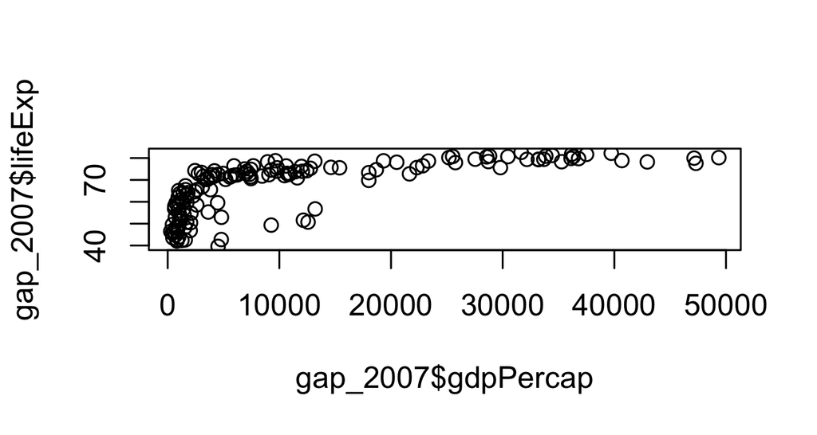

```r
plot(gap_2007$gdpPercap, gap_2007$lifeExp)
```

## Base R: every change is another argument

Color by continent, log the x-axis, add labels. Then draw the legend yourself.

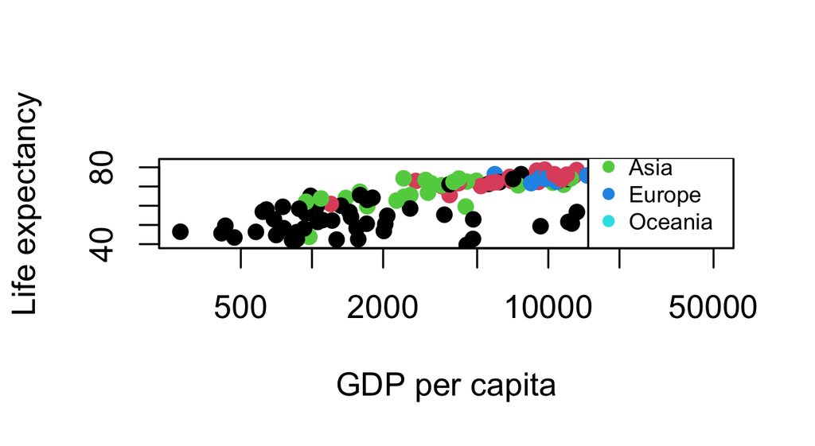

```r
plot(gap_2007$gdpPercap, gap_2007$lifeExp, log = "x",
     col = factor(gap_2007$continent), pch = 19,
     xlab = "GDP per capita", ylab = "Life expectancy")
legend("bottomright", legend = levels(factor(gap_2007$continent)),
       col = 1:5, pch = 19, cex = 0.7)
```

`log = "x"` logs the x-axis, `col = factor(...)` turns continents into color numbers 1–5, and `pch = 19` asks for solid dots. `legend()` is a separate command: nothing connects its colors to the points except you typing `1:5` correctly.

## The same plot in ggplot2

You say what each variable *means* visually. ggplot2 chooses the colors, logs the axis, and builds the legend from that description.

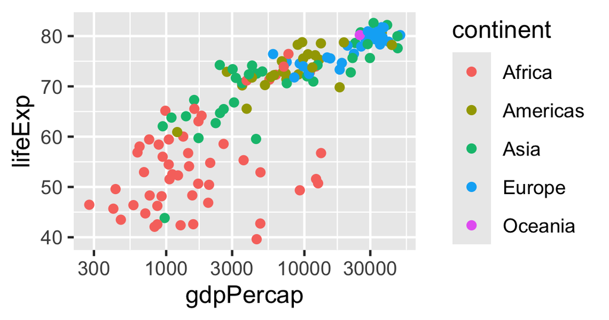

```r
ggplot(gap_2007, aes(x = gdpPercap, y = lifeExp, color = continent)) +
  geom_point() +
  scale_x_log10()
```

`ggplot()` names the data set. `aes()` sets the **aesthetic mappings**: which column controls each visual property, here x, y, and color. `+` adds the next layer: `geom_point()` draws one point per row, and `scale_x_log10()` logs the x-axis. We’ll take each piece slowly in a moment.

## A grammar, not a menu of charts

In *The Grammar of Graphics* (1999), statistician **Leland Wilkinson** argued that any statistical graphic can be built from the same small set of parts, the way any sentence is built from a grammar. Instead of one function per chart type (`barplot()`, `hist()`, `pie()`), you combine parts:

| Part | Question it answers |
| --- | --- |
| Data | Which data set? |
| Aesthetic mappings | Which variable controls position, color or fill, shape, size, or opacity? |
| Geoms | Points, bars, lines, or boxes? |
| Stats | Counted or summarized first? |
| Positions | What happens when marks overlap? |
| Facets (06a) | One panel or several? |
| Scales, themes | How values and labels look (06a) |

Change one part and the others stay put: swap `geom_point()` for another geom and the data and mappings don’t change.

## Who built it

- **Hadley Wickham** wrote ggplot2 as a statistics PhD student at Iowa State. It reached CRAN in 2007; the “gg” stands for *grammar of graphics*. His 2010 paper “A Layered Grammar of Graphics” adapted Wilkinson’s ideas into the layers you add with `+`.
- He then built much of the tidyverse on the same idea. dplyr is described as a *grammar of data manipulation*: small verbs you combine, like `filter()` and `summarize()`.
- ggplot2 is now maintained by a team at Posit, the company behind RStudio. Version 4 arrived in 2025; this course uses 4.0.3.

## Why we use it instead of base R

- **Describe, don’t draw.** Map a variable to color and the colors and legend follow. No hand-typed `1:5`.
- **Revise one part at a time.** Swap a geom, add panels, or change a scale without rewriting the plot.
- **A plot is an object.** Store it as `p`, then add to it, as we’ll do in a moment.
- **It speaks tidy data.** The tibbles you build with dplyr go straight in, and pipelines can end in a plot.
- **It’s what you’ll read.** Current R help, published replication code, and AI coding assistants overwhelmingly write ggplot2. Reading it fluently is part of checking their work in Part II.

Base R still earns a place: `hist(x)` in the Console is the fastest look at one variable.

# From columns to a plot

## Return to Tuesday’s chart

Recreate the small teaching example from 05a. Reordering the factor changes where each service appears; it doesn’t change the counts.

```r
requests <- tibble(service = c("Housing", "Transit", "Water"),
                   requests = c(12, 30, 8)) |>
  mutate(service = fct_reorder(service, requests))
requests
```

```
# A tibble: 3 × 2
  service requests
  <fct>      <dbl>
1 Housing       12
2 Transit       30
3 Water          8
```

## Three ingredients in every ggplot

A ggplot needs all three:

1. **Data:** the data set, such as `requests`.
2. **Aesthetic mappings:** which variables control position, color, or other visual properties, set with `aes()`.
3. **A geom:** the marks to draw, such as points, bars, or lines.

In `requests |> ggplot(aes(x = service, y = requests)) + geom_col()`, the pipe supplies the **data**. It may look like only mappings and a geom follow, but the data is still there. `+` adds components to the plot.

## Read the plotting code

`aes()` maps columns to visual properties: here, horizontal position and bar height. `geom_col()` draws the heights already stored in `requests`.

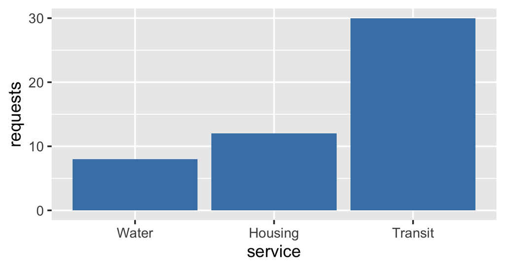

```r
ggplot(requests, aes(x = service, y = requests)) +
  geom_col(fill = "steelblue")
```

## One row, one mark—usually

For a scatterplot, each row usually becomes one point. Other geoms perform a calculation before drawing:

- `geom_bar()` counts rows in each category.
- `geom_histogram()` bins a continuous variable and counts rows in each interval.
- `geom_boxplot()` computes distribution summaries within each category.
- `geom_col()` does no counting; it draws heights already stored in the data.

Ask what one row represents and whether the geom will plot those rows directly or summarize them first.

## Start a scatterplot

Store the plot as `p` so we can build on it. `aes(x = ..., y = ...)` assigns the axes. Without a geom, the plot has axes but no marks. `p + geom_point()` displays a new version without changing `p`; use `<-` to save a change.

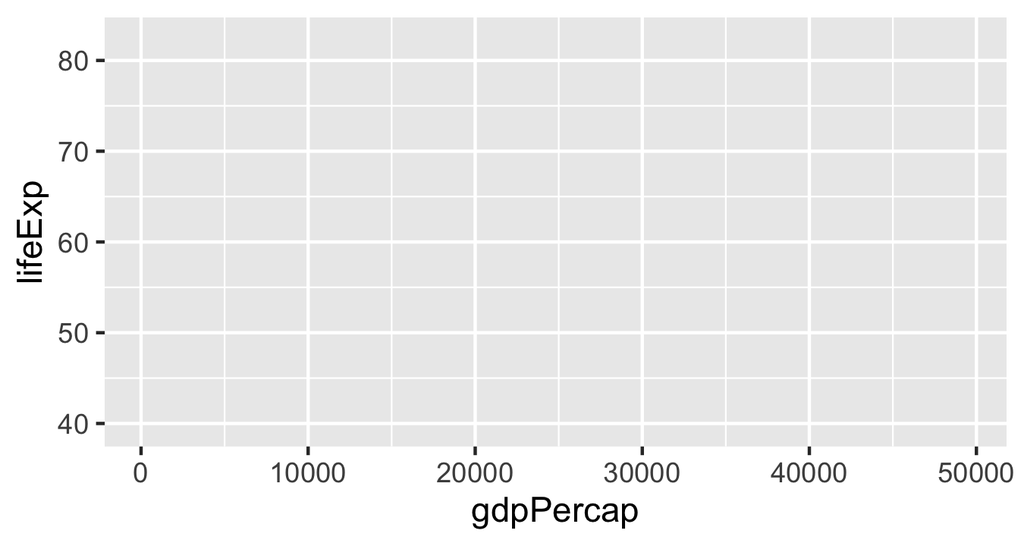

```r
p <- ggplot(gap_2007, aes(x = gdpPercap, y = lifeExp))
p
```

## Add points

`geom_point()` draws one point per country. `color` sets the point color; `alpha` controls opacity from 0 (invisible) to 1 (opaque), helping reveal overlap.

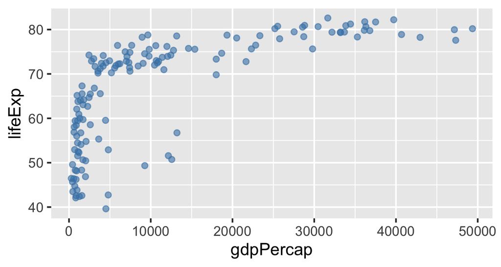

```r
p + geom_point(color = "steelblue", alpha = 0.6)
```

# Mapping and layers

## Mapping versus setting

The last plot **set** `color = "steelblue"` outside `aes()`: every point had the same color, with no legend. Here we **map** `color = continent` inside `aes()`: continent determines each point’s color, and ggplot2 makes a legend. The same distinction applies to size and shape.

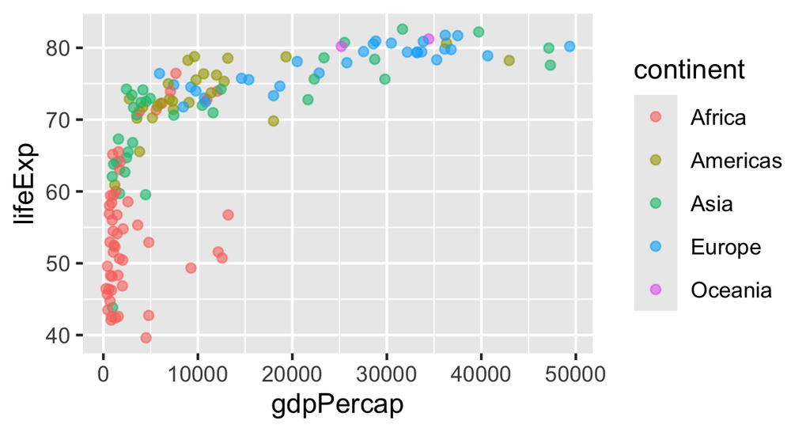

```r
p + geom_point(aes(color = continent), alpha = 0.6)
```

## Your Turn: repair the legend

*~3 minutes.*

This report needs every point in firebrick, with no color legend. Run the code, then fix the placement of `color`. Explain why the original produces a legend labeled “firebrick.”

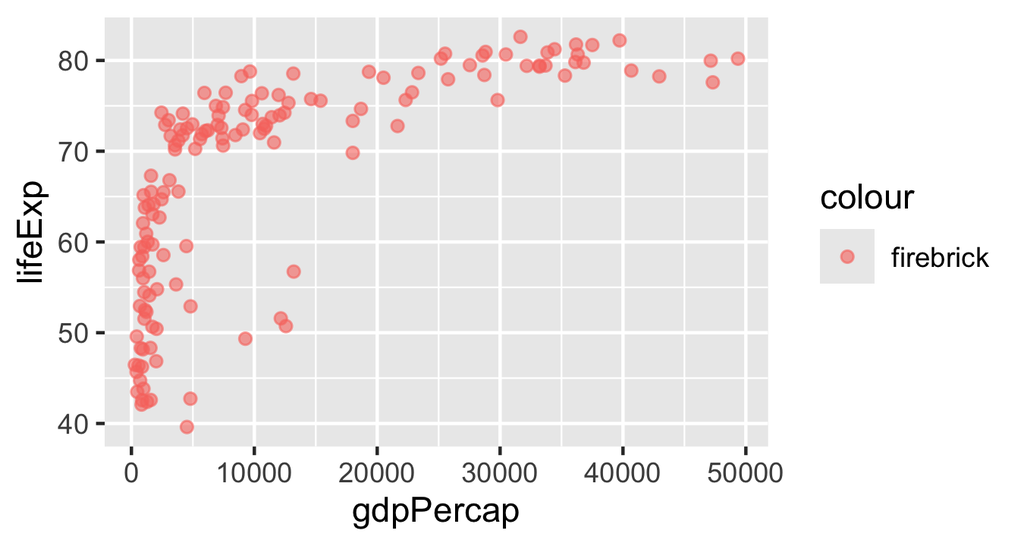

```r
p + geom_point(aes(color = "firebrick"), alpha = 0.6)
```

## Why that legend appeared

Inside `aes()`, `"firebrick"` becomes the name of a one-value category. ggplot2 assigns that category a color from its palette and adds a legend. Move `color` outside `aes()` to set the actual firebrick color for every point.

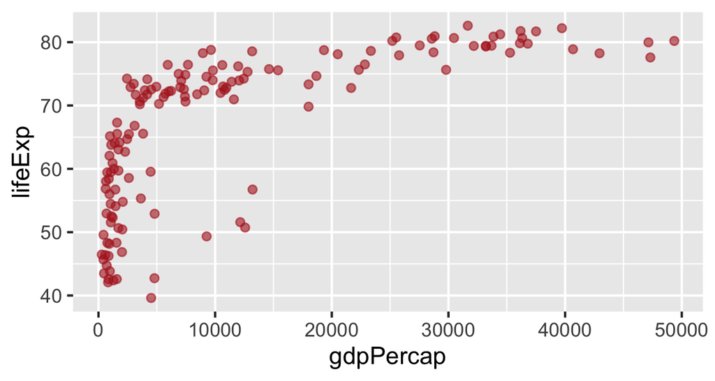

```r
p + geom_point(color = "firebrick", alpha = 0.6)
```

## Spread out the income axis

A log axis spreads out the crowded low-income end: equal ratios get equal space (1,000→10,000→100,000). Values must be positive. Save this version as `p_log`, leaving `p` unchanged; rerunning the chunk rebuilds `p_log`.

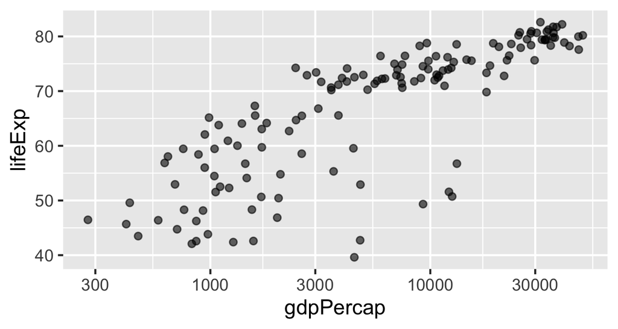

```r
p_log <- p + scale_x_log10()
p_log + geom_point(alpha = 0.6)
```

## Shape can show a category

`shape = continent` maps each continent to a different point symbol. The legend follows the mapping. Shape can work in black and white, though several groups are harder to distinguish than a few.

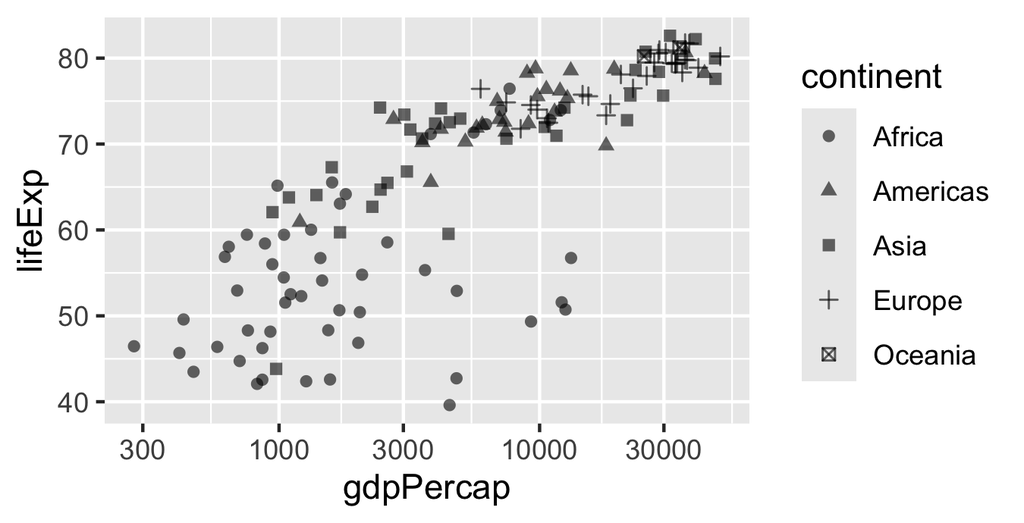

```r
p_log + geom_point(aes(shape = continent), alpha = 0.6)
```

## Add a fitted line

`geom_smooth(method = "lm")` fits a linear regression; `se = FALSE` hides its confidence band. Here it fits life expectancy against log GDP because the axis transformation happens before fitting.

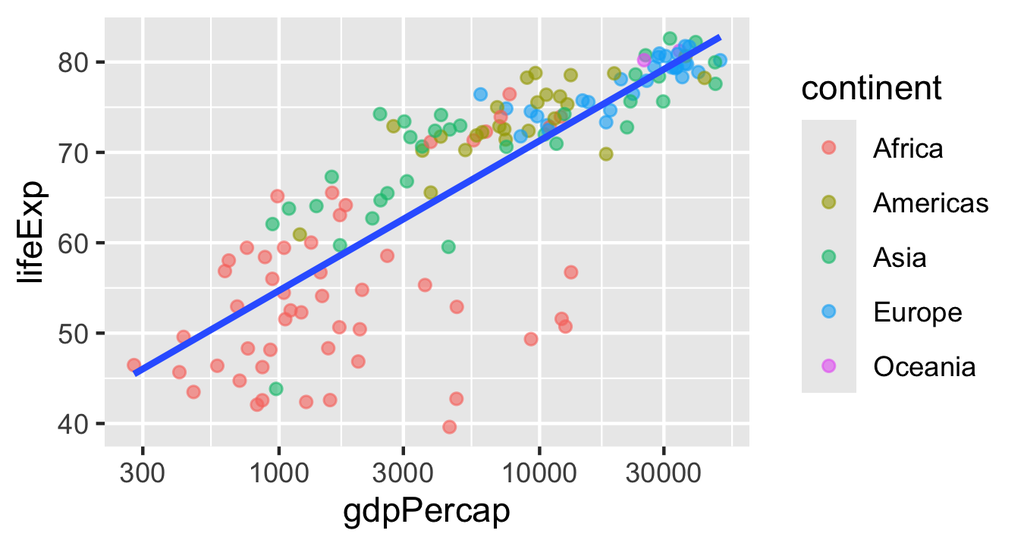

```r
p_log +
  geom_point(aes(color = continent), alpha = 0.6) +
  geom_smooth(method = "lm", se = FALSE)
```

## What each layer inherits

`ggplot(gap_2007, aes(x = gdpPercap, y = lifeExp))` gives every geom the same data and x/y mappings unless that geom supplies its own.

- In the previous plot, `geom_point(aes(color = continent), alpha = 0.6)` adds a color mapping and sets opacity **for the points only**. The smoother inherits x/y, but not that point-layer color mapping.
- A geom can also supply its own data with `data =`, or its own mappings with `aes()`. Those choices affect that layer; the others keep their defaults.

## Where the mapping lives

Now move `color = continent` into `ggplot()`. Both geoms inherit it, so the smoother fits a line for each continent. Oceania has just two countries, so its fitted line tells us little about a regional relationship.

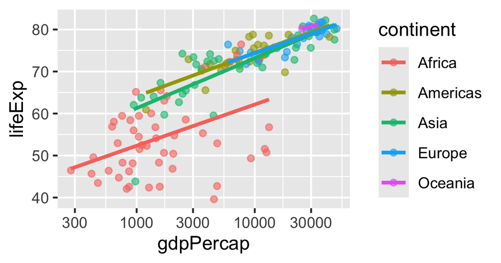

```r
ggplot(gap_2007, aes(x = gdpPercap, y = lifeExp, color = continent)) +
  geom_point(alpha = 0.6) +
  geom_smooth(method = "lm", se = FALSE) +
  scale_x_log10()
```

## Reveal overlapping points

The file has nearly 18,000 respondents. Sample 1,000 rows, then spread tied ages horizontally with jitter. `width = 0.2` controls the sideways spread, `height = 0` keeps each age exact, and `size = 0.8` sets one small point size. These are settings, not mappings. The points show individual observations, not the full-sample counts.

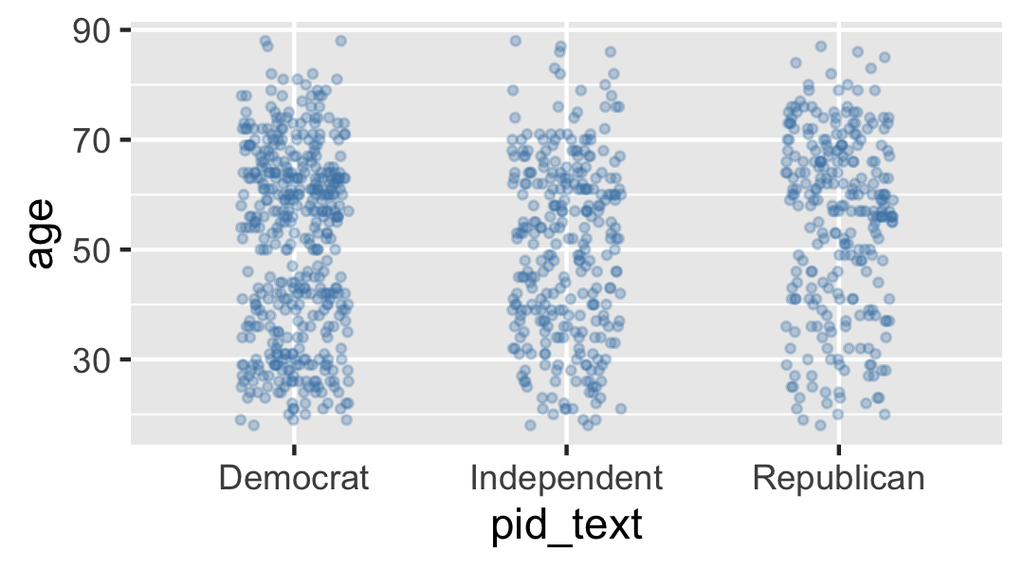

```r
set.seed(6394)
cces_sample <- cces |> slice_sample(n = 1000)
ggplot(cces_sample, aes(x = pid_text, y = age)) +
  geom_jitter(width = 0.2, height = 0, alpha = 0.3,
              size = 0.8, color = "steelblue")
```

# Choose a plot for the question

## Show a distribution

A histogram groups ages into intervals and counts respondents. `binwidth = 5` means five-year intervals; wider bins hide detail. `fill` colors the bars, `color` their borders, and `labs()` supplies readable axis labels.

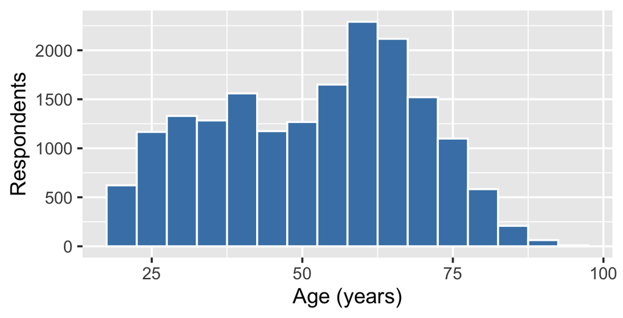

```r
ggplot(cces, aes(x = age)) +
  geom_histogram(binwidth = 5, fill = "steelblue", color = "white") +
  labs(x = "Age (years)", y = "Respondents")
```

## Read a boxplot

Use a boxplot to compare continuous distributions across categories.

- The line is the median; the box spans the middle 50 percent.
- Whiskers reach the most extreme observations within 1.5 box lengths of the box.
- Points beyond the whiskers are flagged by this rule; they aren’t necessarily errors.

A boxplot hides detail about the distribution’s shape, so it can be useful to inspect a histogram too.

## Compare age across parties

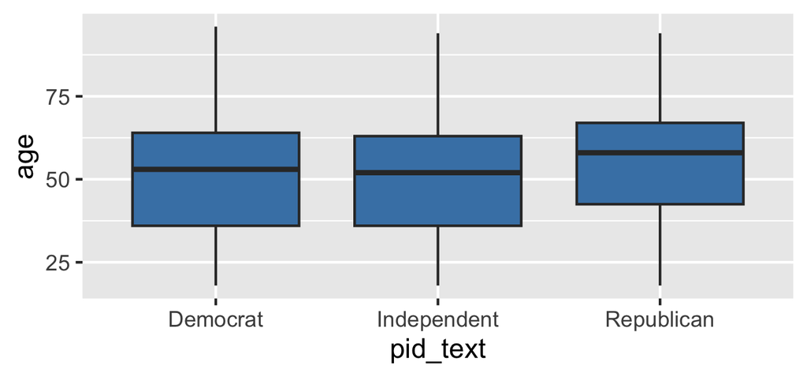

```r
ggplot(cces, aes(x = pid_text, y = age)) +
  geom_boxplot(fill = "steelblue")
```

## Count rows with bars

`geom_bar()` counts respondents in each category. Supply `x` only; ggplot computes the heights.

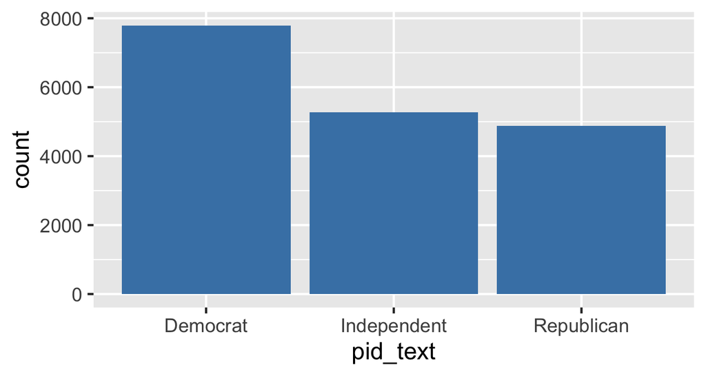

```r
ggplot(cces, aes(x = pid_text)) +
  geom_bar(fill = "steelblue")
```

## Draw counts you’ve already computed

This makes the same chart. `count()` creates the counts; `geom_col()` draws them. Reorder the factor before plotting when a count-based order would help the reader.

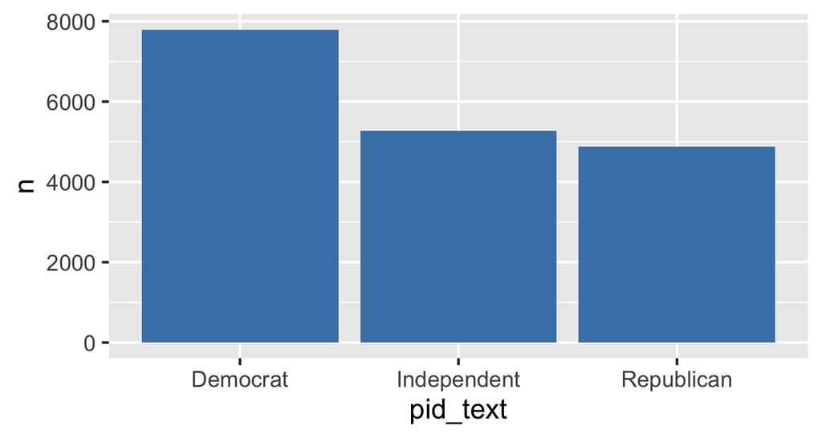

```r
party_counts <- cces |> count(pid_text)
ggplot(party_counts, aes(x = pid_text, y = n)) +
  geom_col(fill = "steelblue")
```

## Put frequent categories first

Recall `fct_infreq()` from 05a. It orders categories by how often they occur, while `geom_bar()` performs the counting.

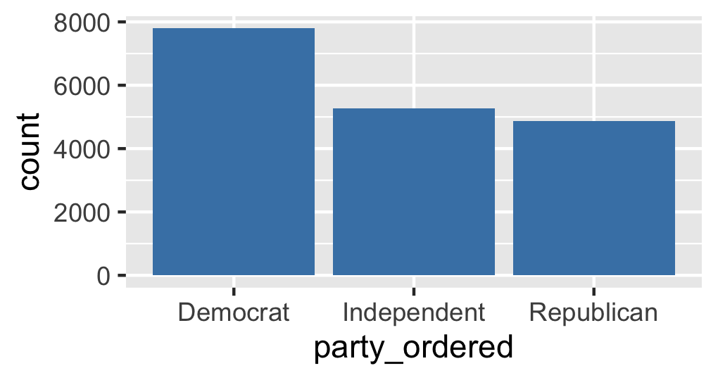

```r
cces |>
  mutate(party_ordered = fct_infreq(pid_text)) |>
  ggplot(aes(x = party_ordered)) +
  geom_bar(fill = "steelblue")
```

Use this order when frequency is the comparison. Preserve a substantive order when categories have one.

## Compare counts within groups

Compare party counts by voter-registration status. Map party to `fill` to distinguish the bars. `position = "dodge"` places them side by side; without it, bars stack.

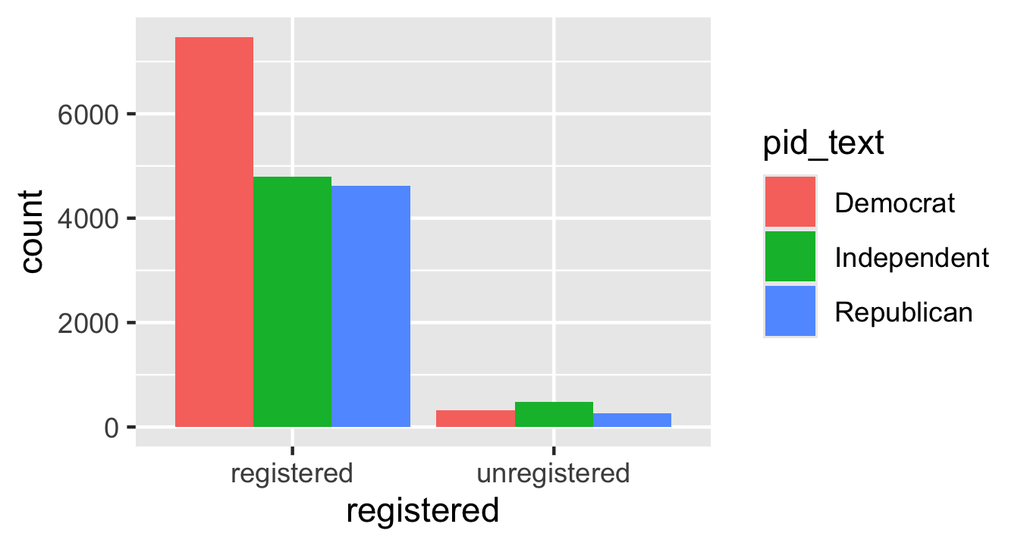

```r
ggplot(cces, aes(x = registered, fill = pid_text)) +
  geom_bar(position = "dodge")
```

## Compare composition instead

`position = "fill"` makes each registration-status bar sum to 1. It compares party shares but hides sample sizes: the unregistered group has 1,069 respondents versus 16,880 registered respondents. The `fill` mapping chooses colors; the `"fill"` position rescales heights.

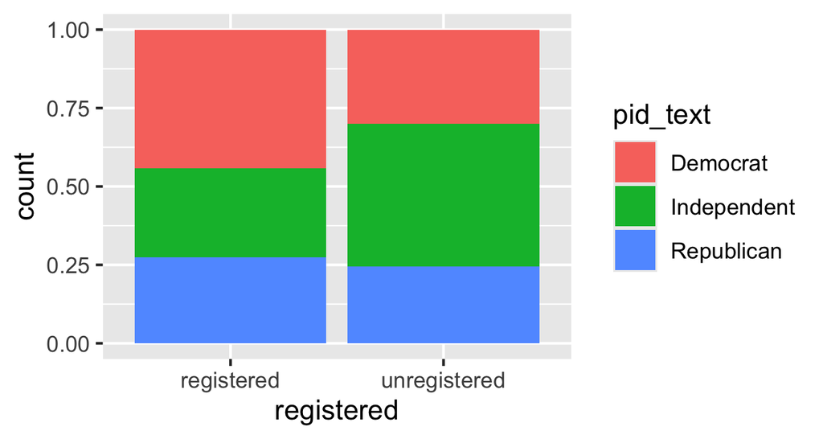

```r
ggplot(cces, aes(x = registered, fill = pid_text)) +
  geom_bar(position = "fill")
```

## Your Turn: change the denominator

*~3 minutes.*

Now show the registration composition within each party. Choose the x and fill mappings and a position so each party’s bar sums to 1. Whose respondents form the denominator in each bar, and how does that differ from the previous chart?

```r
# Fill in, then delete the eval:false line and re-render.
ggplot(cces, aes(x = ___, fill = ___)) +
  geom_bar(position = ___)
```

## Check missing values before plotting

Many geoms omit rows with missing values and usually print a warning. Check what will be removed so the plotted sample is a deliberate choice.

```r
states_2000 |>
  summarize(rows = n(),
            missing_pid = sum(is.na(pid)),
            missing_policy = sum(is.na(pollib_median)))
```

```
# A tibble: 1 × 3
   rows missing_pid missing_policy
  <int>       <int>          <int>
1    49           0              1
```

```r
states_2000 |>
  filter(is.na(pid) | is.na(pollib_median)) |>
  select(state, pid, pollib_median)
```

```
# A tibble: 1 × 3
  state                  pid pollib_median
  <chr>                <dbl>         <dbl>
1 District of Columbia  0.69            NA
```

Keep this row in mind: the lab removes it with `drop_na()`.

## Show change over time

Summarize before drawing the line. Each point on this line is the median across countries in that year, not a population-weighted world average. `geom_line()` connects values in x order.

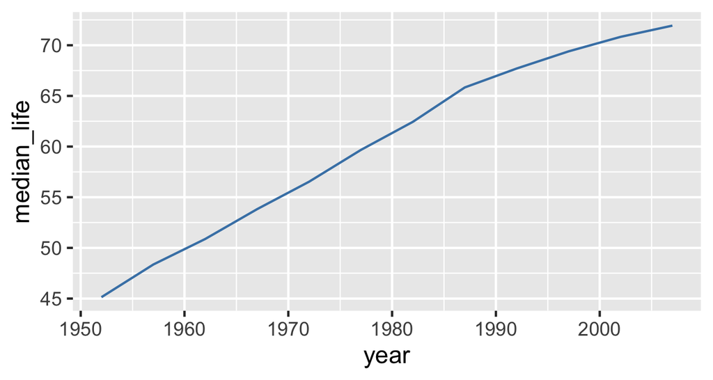

```r
gap |>
  group_by(year) |>
  summarize(median_life = median(lifeExp)) |>
  ggplot(aes(x = year, y = median_life)) +
  geom_line(color = "steelblue")
```

## Multiple lines need groups

Summarize by continent and year to create one series per continent; `.groups = "drop"` returns an ungrouped tibble afterward. Mapping `color = continent` also tells `geom_line()` which observations belong to each line.

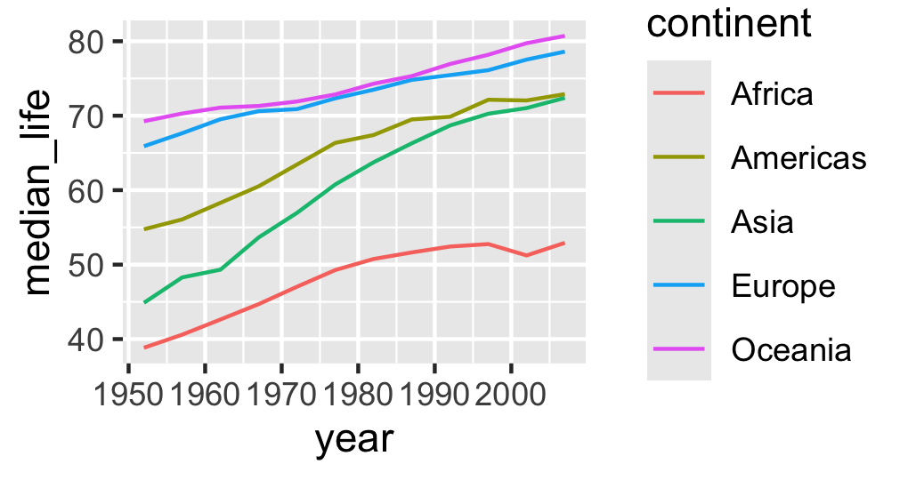

```r
gap |>
  group_by(continent, year) |>
  summarize(median_life = median(lifeExp), .groups = "drop") |>
  ggplot(aes(x = year, y = median_life, color = continent)) +
  geom_line()
```

Without a grouping aesthetic, ggplot may connect observations that belong to different series. Color supplies the grouping here; `group = continent` can do so without color.

## Choose from the question

| What do you need to see? | Start with |
| --- | --- |
| A continuous distribution | Histogram |
| A continuous distribution by category | Boxplot |
| A relationship between two numbers | Scatterplot |
| Counts or computed category totals | Bar or column chart |
| Change over time | Line chart |

Ask what one row represents before deciding what the plot should count or summarize.

# Lab

## Lab: compare state-policy patterns

*~12 minutes in class; finish the remaining tasks by 7:00 PM Monday, September 28.*

Start the three-task lab in your workbook. After about twelve minutes, we’ll stop and save your progress.

1. Drop the incomplete jurisdiction, run the state scatter, and add regional colors.
2. Order regions by median policy liberalism and draw boxplots.
3. Map region to shape, then compare it with the colored scatter.

Use the supplied year-2000 data. The plots use the 48 complete states; DC, which you inspected earlier, is excluded. Write interpretations beneath the figures.

## Finalize 05b

- After the twelve-minute lab block, save and render your progress; keep unfinished chunks at `eval: false`.
- Inspect your changes, commit with a message such as `"Start 05b regional policy plots"`, and push before leaving.
- Confirm the commit on GitHub. If rendering fails, record the error and push the saved workbook anyway.
- Finish the remaining tasks by 7:00 PM Monday, September 28, then render again, commit, and push.

## Before Next Class

- Tuesday, September 29: small multiples, scales, color, themes, labels, annotation, and saving figures.
- Read Healy, *Data Visualization*, chapter 5.
- Optional practice: [ModernDive chapter 2](https://moderndive.com/v2/02-visualization.html) and [Heiss’s visualization primer](https://r-primers.andrewheiss.com/basics/01-visualization-basics/).

# If Time Remains

## Additional teaching and practice

These activities are optional, not extra-credit assignments. The lab doesn’t depend on them.

## Extension 1a: Why small multiples?

*~18 minutes for this optional sequence.*

Today’s lab puts all states on one scatterplot and identifies regions with color or shape. A **small multiple** gives each region its own copy of the same plot. It is easier to inspect a pattern within one region when its points are not mixed with the others.

The tradeoff is distance: your eye must move between panels to compare states from different regions. The same axes and marks across panels make that comparison possible.

## Extension 1b: `facet_wrap()` for one variable

`facet_wrap(~ region.name)` makes one panel for each region. `ncol = 2` arranges the four panels in two columns; `nrow` could set the number of rows instead. The `~` introduces the grouping variable. It does not fit a regression.

```r
states_plot <- states_2000 |> drop_na(pid, pollib_median)
ggplot(states_plot, aes(x = pid, y = pollib_median)) +
  geom_point() +
  facet_wrap(~ region.name, ncol = 2)
```

## Extension 1c: Region panels

Each panel contains only its region’s states. The axes retain the same scales.

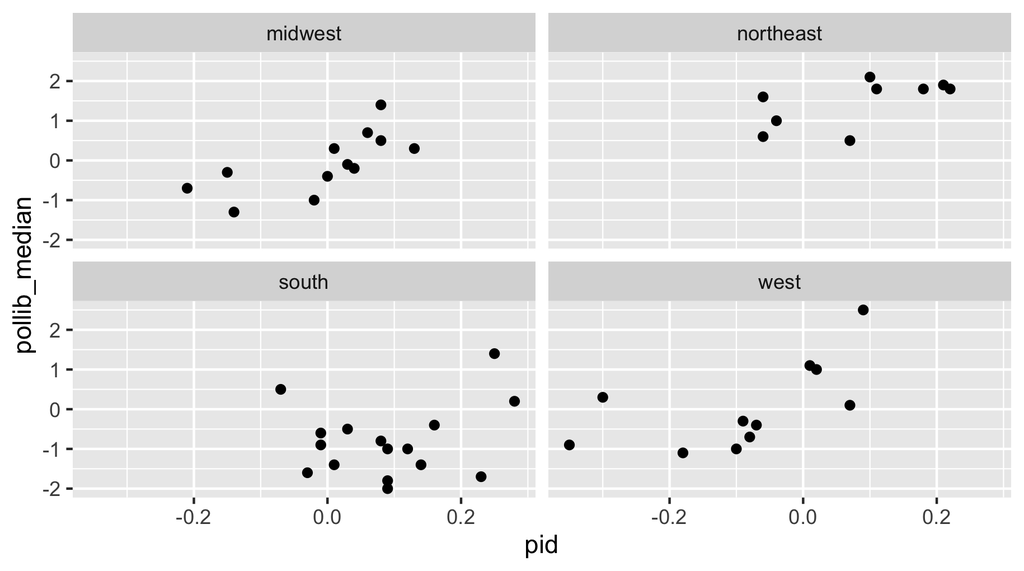

## Extension 1d: Shared or separate y-axes?

The default is `scales = "fixed"`: every panel uses the same x- and y-axis ranges. The same height then means the same policy score in every region. If the question is about the pattern *within* each region, `scales = "free_y"` gives each panel its own y-axis while keeping x shared.

```r
ggplot(states_plot, aes(x = pid, y = pollib_median)) +
  geom_point() +
  facet_wrap(~ region.name, ncol = 2, scales = "free_y")
```

## Extension 1e: Free y-axes

The points fill more of each panel. Read the y-axis labels before comparing panels: equal heights may now represent different policy scores.

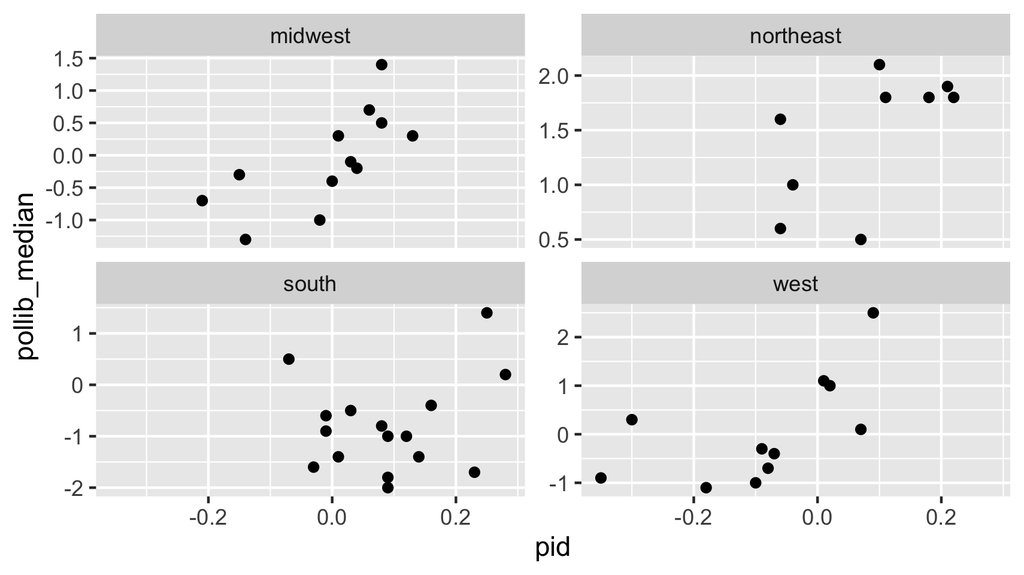

## Extension 1f: Order the panels

Panels follow the facet variable’s factor levels. This reuses `fct_reorder()` from 05a: order regions by their median policy score rather than alphabetically. The state rows and their scores do not change.

```r
states_ordered <- states_plot |>
  mutate(region_ordered = fct_reorder(region.name, pollib_median))
levels(states_ordered$region_ordered)
ggplot(states_ordered, aes(x = pid, y = pollib_median)) +
  geom_point() +
  facet_wrap(~ region_ordered, ncol = 2)
```

## Extension 1g: Ordered region panels

The panels now run South, West, Midwest, Northeast, from lower to higher median policy liberalism. Shared axes still let us compare their positions directly.

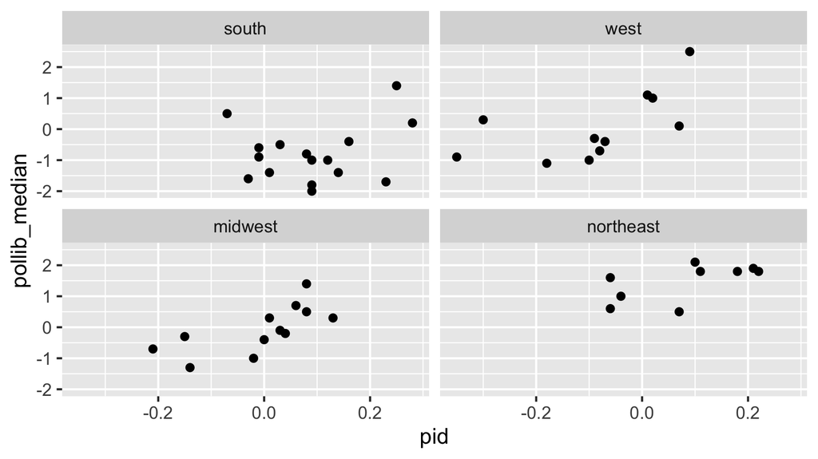

## Extension 1h: `facet_grid()` for two variables

`facet_grid(rows ~ columns)` crosses two variables. Here party lean determines the rows and region determines the columns. Read down a column to compare party lean within a region; read across a row to compare regions with the same lean.

```r
states_grid <- states_ordered |>
  mutate(party_lean = if_else(pid > 0, "More Democratic", "More Republican"))
ggplot(states_grid, aes(x = pid, y = pollib_median)) +
  geom_point() +
  facet_grid(party_lean ~ region_ordered)
```

## Extension 1i: Region by party lean

The grid has eight possible panels, but some contain few states. Faceting cannot make a thin subgroup more informative than the data allow.

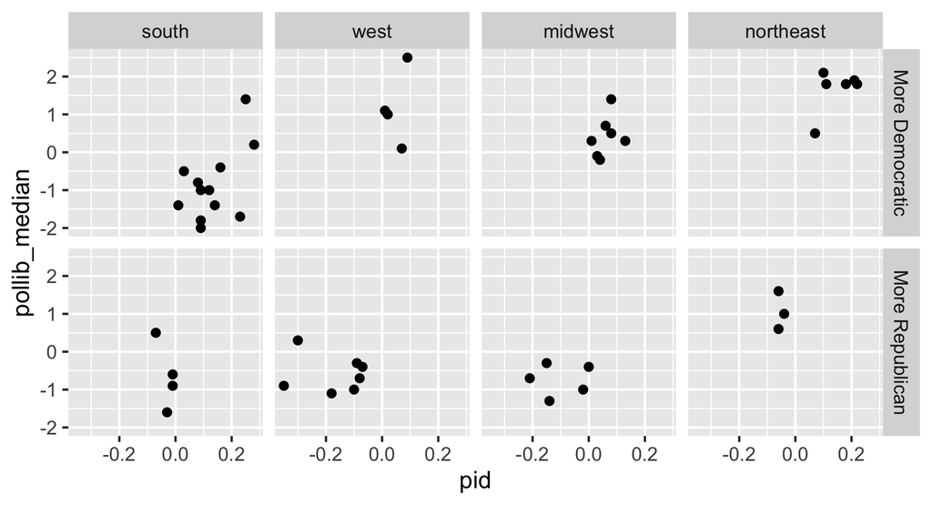

## Extension 1j: Which layout fits?

| Question | Facet choice |
| --- | --- |
| One grouping variable | `facet_wrap(~ region.name)` |
| Two grouping variables | `facet_grid(party_lean ~ region_ordered)` |

Use shared scales for comparisons *between* panels. Free a scale when the range hides the pattern *within* a panel, and label the axes clearly. Order the facet variable before plotting when panel order carries meaning.

Which comparison is easier in the panels, and which is easier on the single colored plot from the lab?

We’ll cover small multiples in 06a if we do not reach this section today.

## Extension 2a: Put long labels on the y-axis

*~8–10 minutes.*

Country names crowd each other under vertical bars. Map the category to `y` instead, and `geom_col()` draws horizontal bars with readable names. `slice_max(pop, n = 10)` keeps the 10 most populous countries, `pop / 1e6` shows population in millions, and `y = NULL` drops the axis title because the names label themselves.

```r
gap_2007 |>
  slice_max(pop, n = 10) |>
  ggplot(aes(x = pop / 1e6, y = fct_reorder(country, pop))) +
  geom_col(fill = "steelblue") +
  labs(x = "Population, 2007 (millions)", y = NULL)
```

## Extension 2b: Horizontal bars

The names fit along the y-axis, and longer bars mean larger populations.

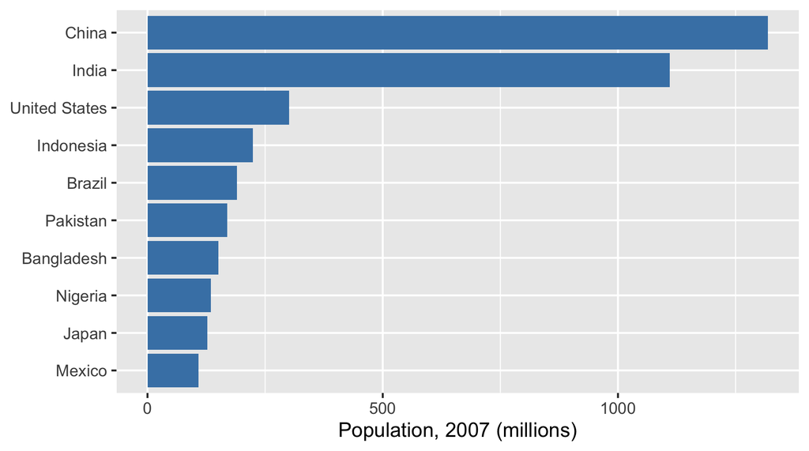

## Extension 2c: Sort by a different measure

Keep the same 10 countries but show life expectancy: put `lifeExp` on x and reorder the countries by `lifeExp`. Then swap the mappings so `country` is on x. What happens to the names, and which version would you put in a report?

Make the edits in the previous chunk. No new data import is needed.